# Summary Plots and Statistics for Drifting Buoy Sperm Whale Events

#### Event ID: 6663.241005151800.wav

Time: 2024-10-05 15:18UTC to 2024-10-05 15:24UTC

Event contains 2936 original clicks, **1468 valid clicks** after filtering.

##### Click plots and table

SNR histogram includes all filtered clicks. Other plots contain only clicks with SNR >= 15 dB (**n = 1030 clicks**) .

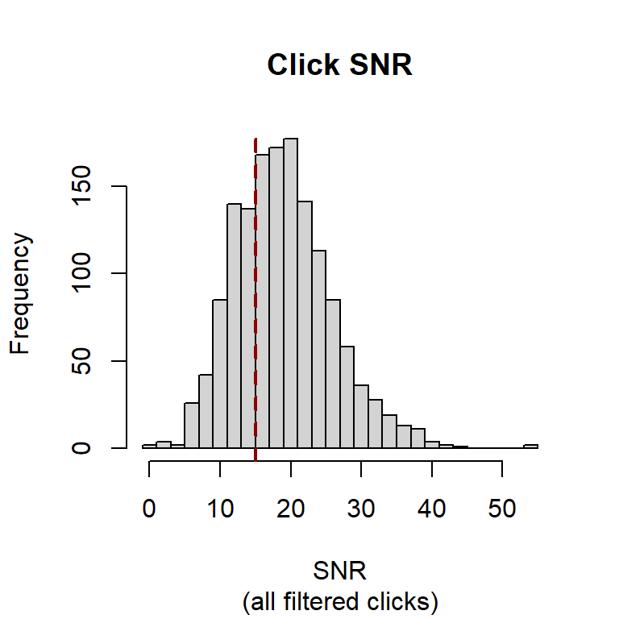

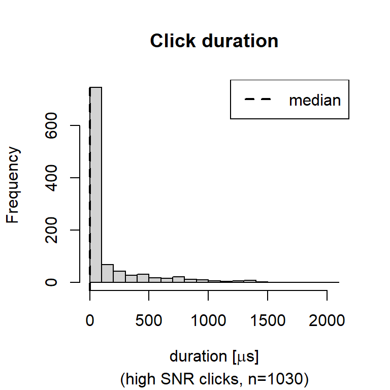

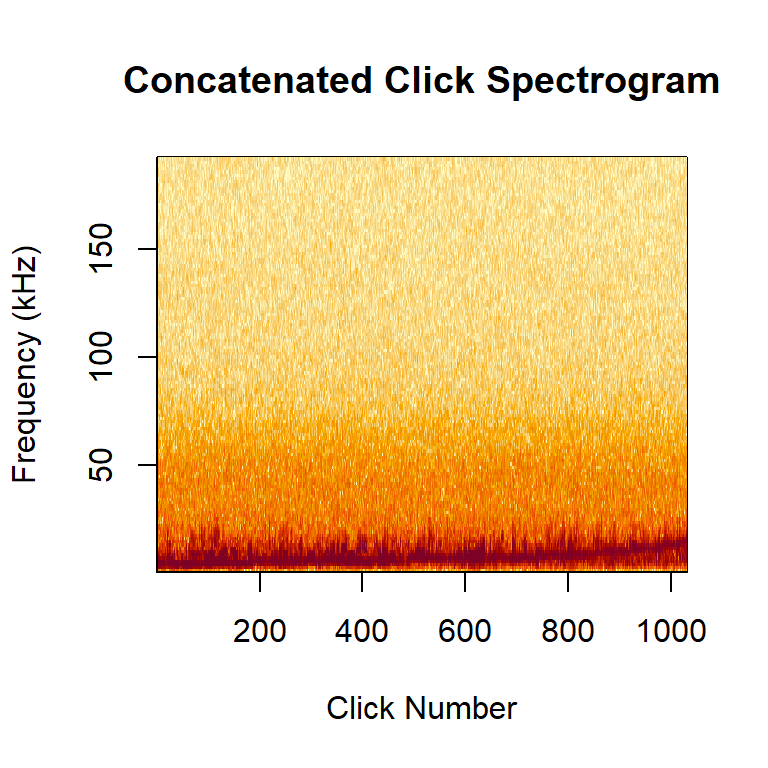

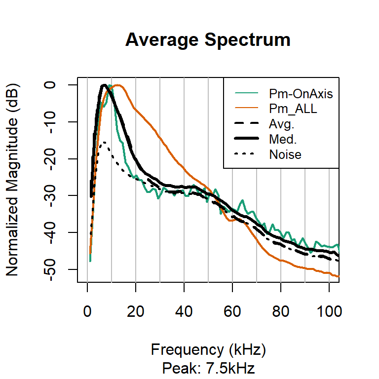

Median statistics for 1030 high SNR clicks with SNR >= 15 dB.

| parameter | value |
| --- | --- |
| Median Peak Frequency [kHz] | 6 |
| Median 3dB Center Frequency [kHz] | 5.8 |
| Median 10dB Center Frequency [kHz] | 5.89 |
| Median 3dB Bandwidth [kHz] (lower-upper) | 1.12 (5.12 - 6.42) |
| Median 10dB Bandwidth [kHz] (lower-upper) | 3.18 (3.96 - 7.78) |
| Median duration [μs] (25-75 percentile) | 0 (0 - 138) |

#### Event ID: 6663.241005152400.wav

Time: 2024-10-05 15:24UTC to 2024-10-05 15:30UTC

Event contains 2792 original clicks, **1396 valid clicks** after filtering.

##### Click plots and table

SNR histogram includes all filtered clicks. Other plots contain only clicks with SNR >= 15 dB (**n = 953 clicks**) .

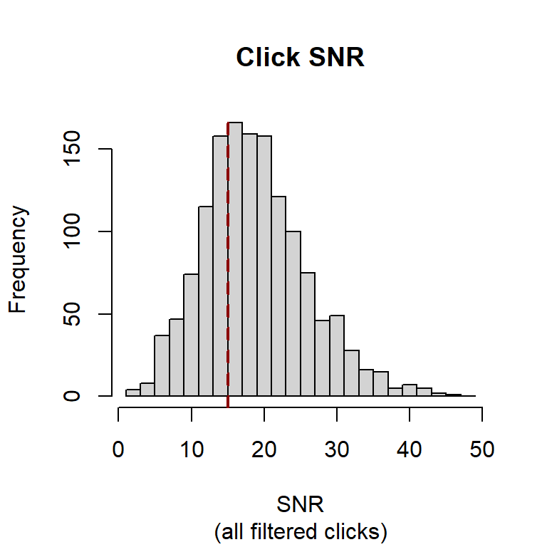

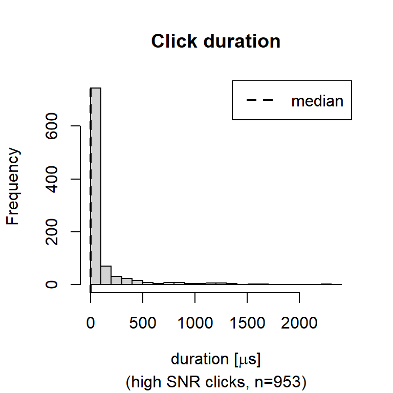

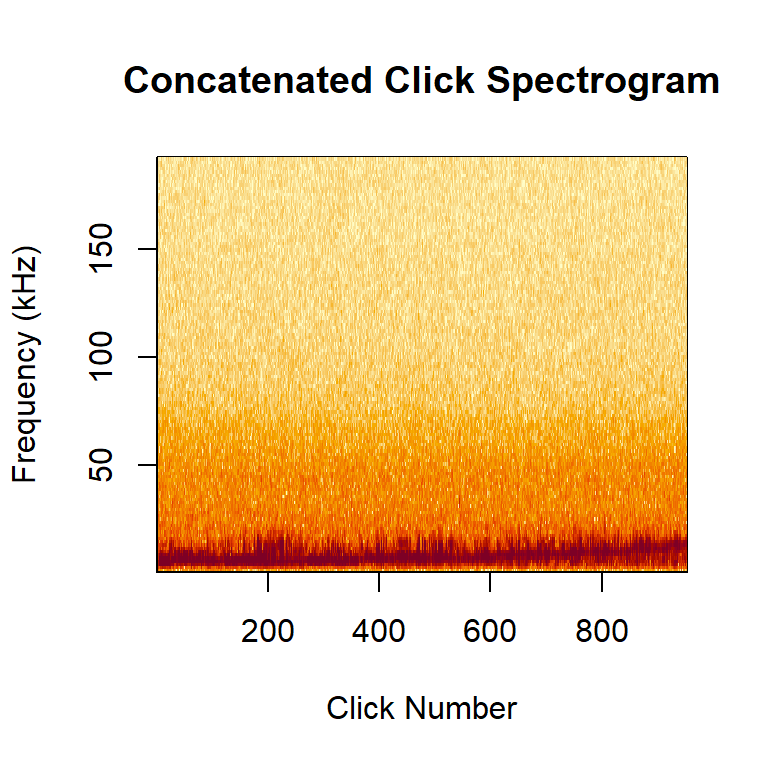

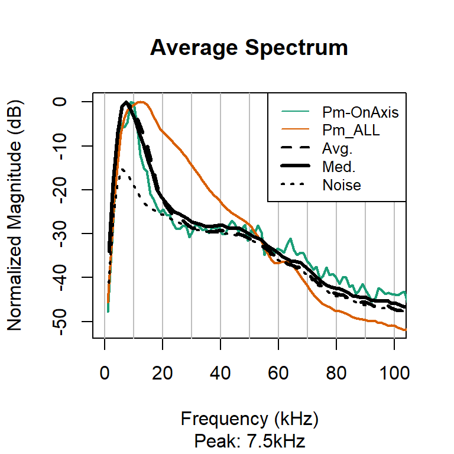

Median statistics for 953 high SNR clicks with SNR >= 15 dB.

| parameter | value |
| --- | --- |
| Median Peak Frequency [kHz] | 6.4 |
| Median 3dB Center Frequency [kHz] | 5.95 |
| Median 10dB Center Frequency [kHz] | 6.31 |
| Median 3dB Bandwidth [kHz] (lower-upper) | 1.24 (5.17 - 6.78) |
| Median 10dB Bandwidth [kHz] (lower-upper) | 3.79 ( 4.1 - 8.54) |
| Median duration [μs] (25-75 percentile) | 0 (0 - 100) |

#### Event ID: 6663.241011140001.wav

Time: 2024-10-11 14:00UTC to 2024-10-11 14:06UTC

Event contains 936 original clicks, **468 valid clicks** after filtering.

##### Click plots and table

SNR histogram includes all filtered clicks. Other plots contain only clicks with SNR >= 15 dB (**n = 358 clicks**) .

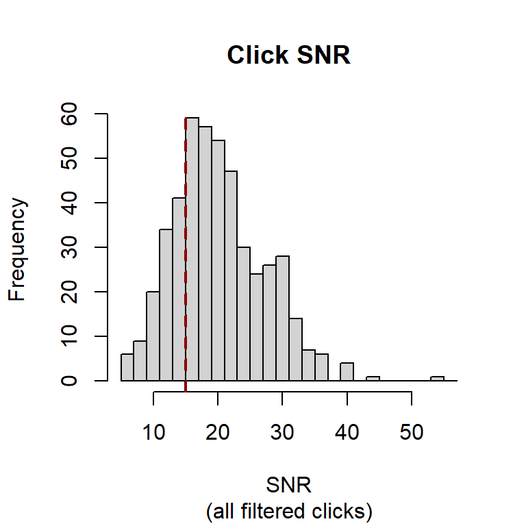

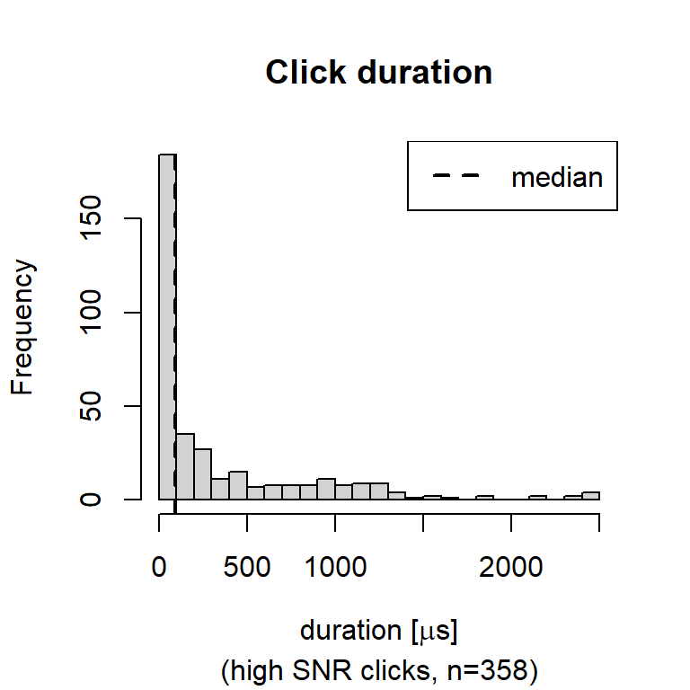

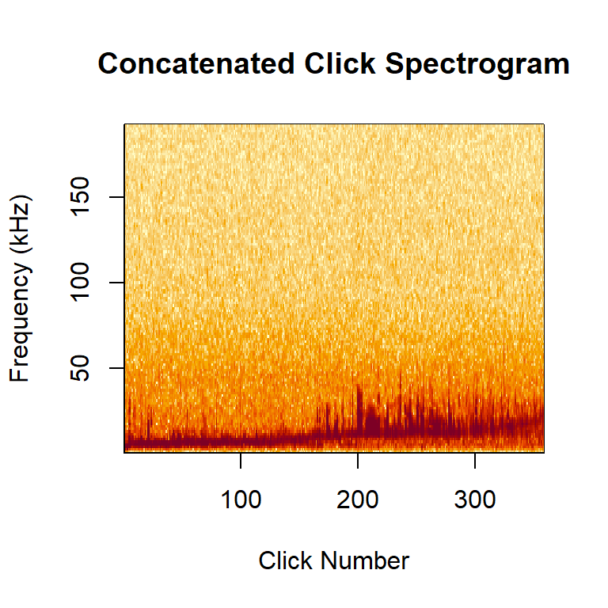

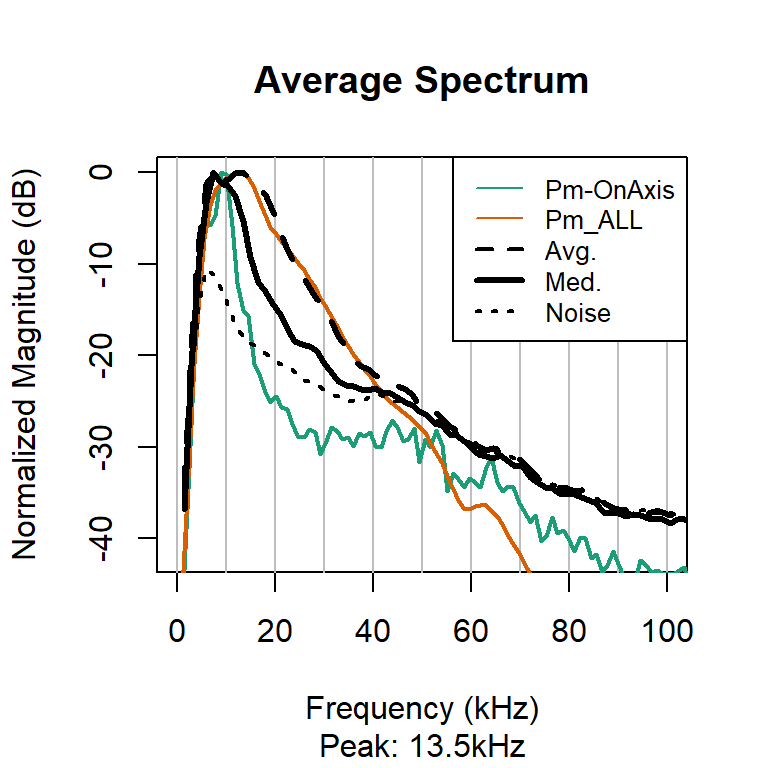

Median statistics for 358 high SNR clicks with SNR >= 15 dB.

| parameter | value |
| --- | --- |
| Median Peak Frequency [kHz] | 9.6 |
| Median 3dB Center Frequency [kHz] | 8.68 |
| Median 10dB Center Frequency [kHz] | 8.89 |
| Median 3dB Bandwidth [kHz] (lower-upper) | 1.63 ( 7.9 - 9.73) |
| Median 10dB Bandwidth [kHz] (lower-upper) | 5.46 (6.07 - 11.7) |
| Median duration [μs] (25-75 percentile) | 95 (8 - 458) |

#### Event ID: 6663.241011140601.wav

Time: 2024-10-11 14:06UTC to 2024-10-11 14:12UTC

Event contains 1702 original clicks, **851 valid clicks** after filtering.

##### Click plots and table

SNR histogram includes all filtered clicks. Other plots contain only clicks with SNR >= 15 dB (**n = 653 clicks**) .

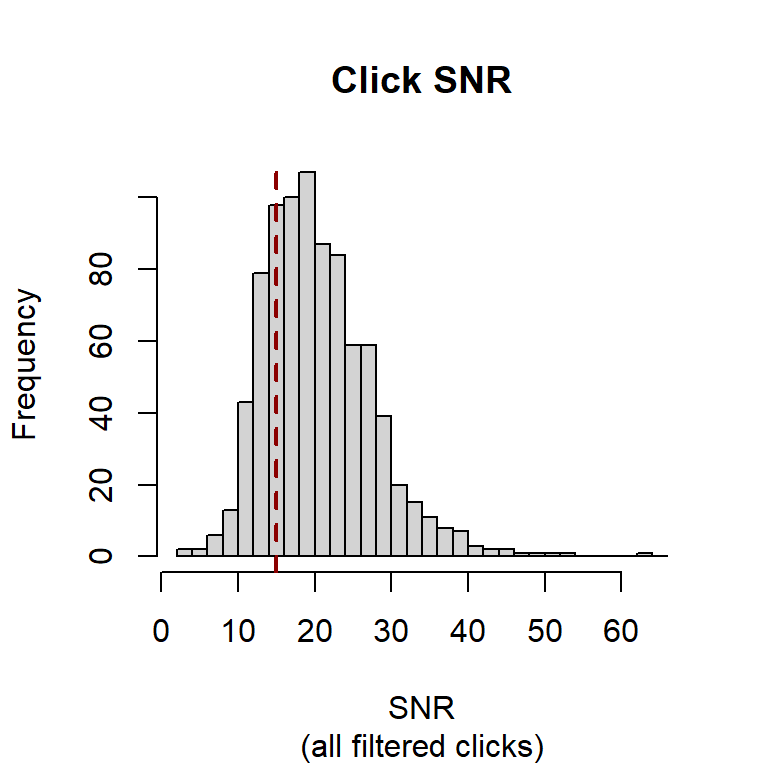

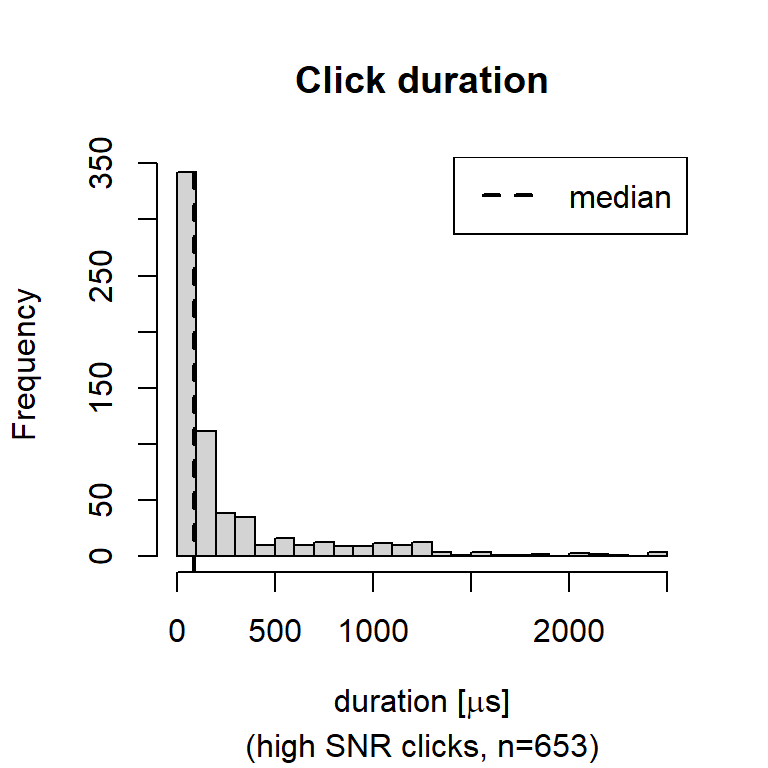

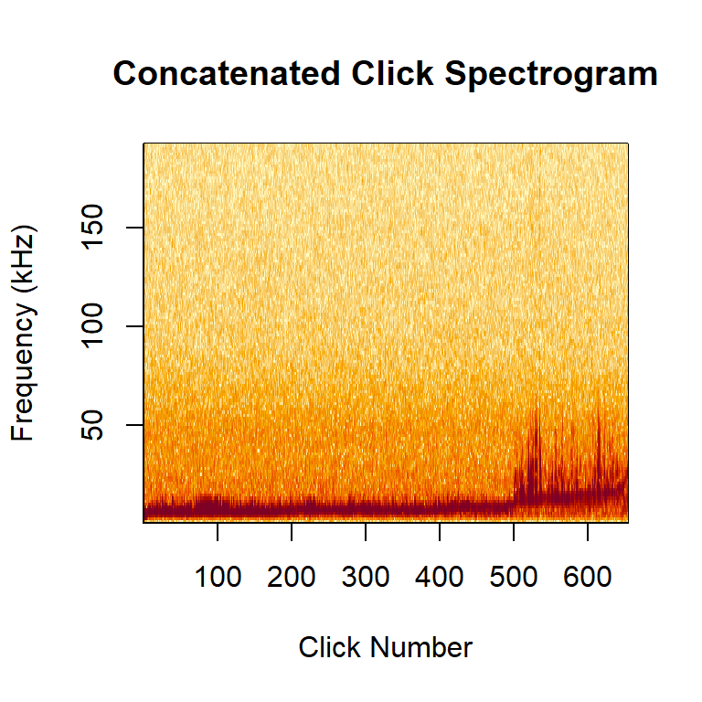

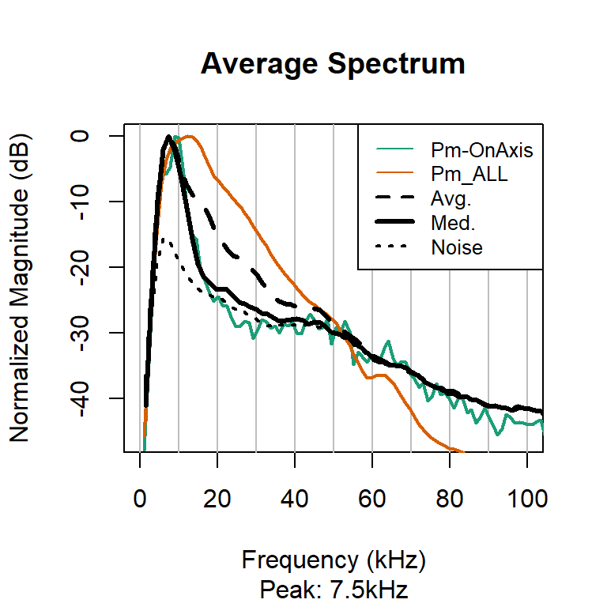

Median statistics for 653 high SNR clicks with SNR >= 15 dB.

| parameter | value |
| --- | --- |
| Median Peak Frequency [kHz] | 6.4 |
| Median 3dB Center Frequency [kHz] | 6.22 |
| Median 10dB Center Frequency [kHz] | 6.58 |
| Median 3dB Bandwidth [kHz] (lower-upper) | 1.7 (5.32 - 7.26) |
| Median 10dB Bandwidth [kHz] (lower-upper) | 4.78 (4.04 - 9.12) |
| Median duration [μs] (25-75 percentile) | 91 (0 - 287) |

#### Event ID: 6663.241011141201.wav

Time: 2024-10-11 14:12UTC to 2024-10-11 14:18UTC

Event contains 1484 original clicks, **742 valid clicks** after filtering.

##### Click plots and table

SNR histogram includes all filtered clicks. Other plots contain only clicks with SNR >= 15 dB (**n = 555 clicks**) .

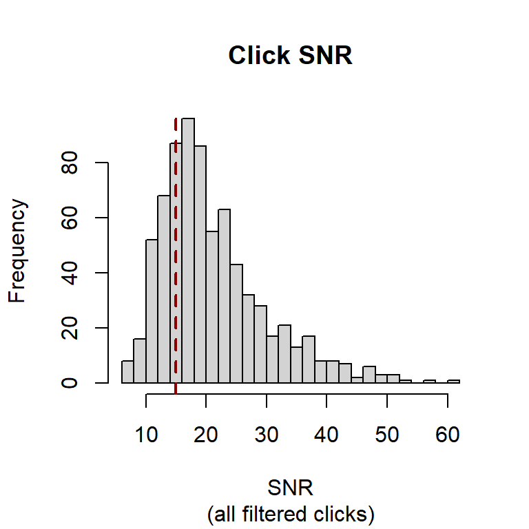

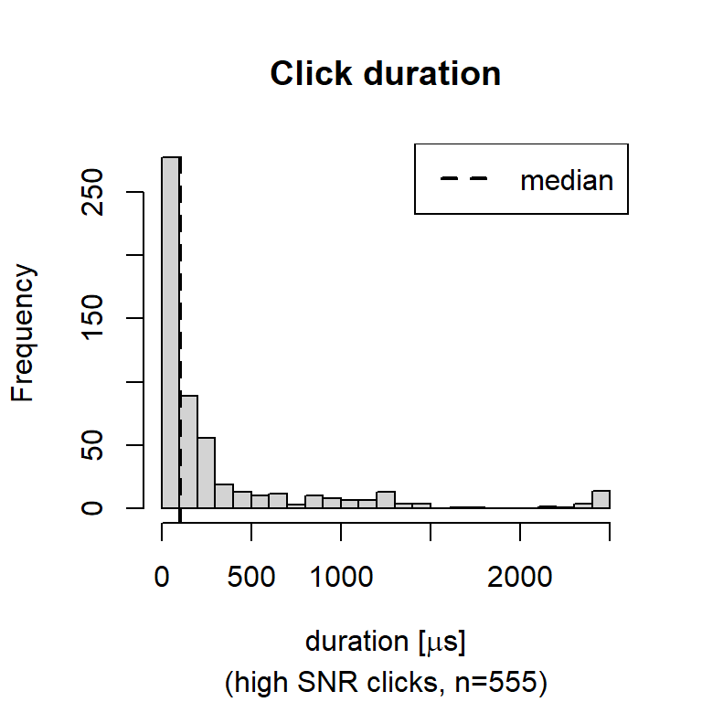

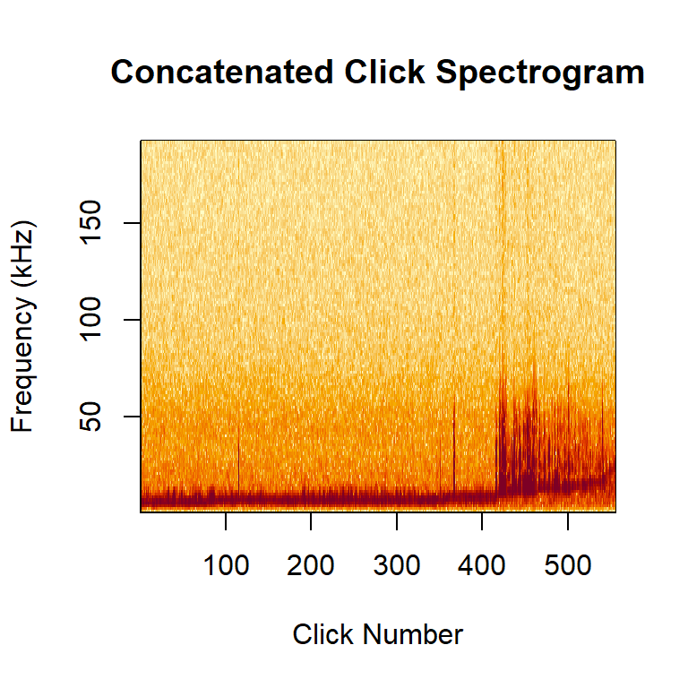

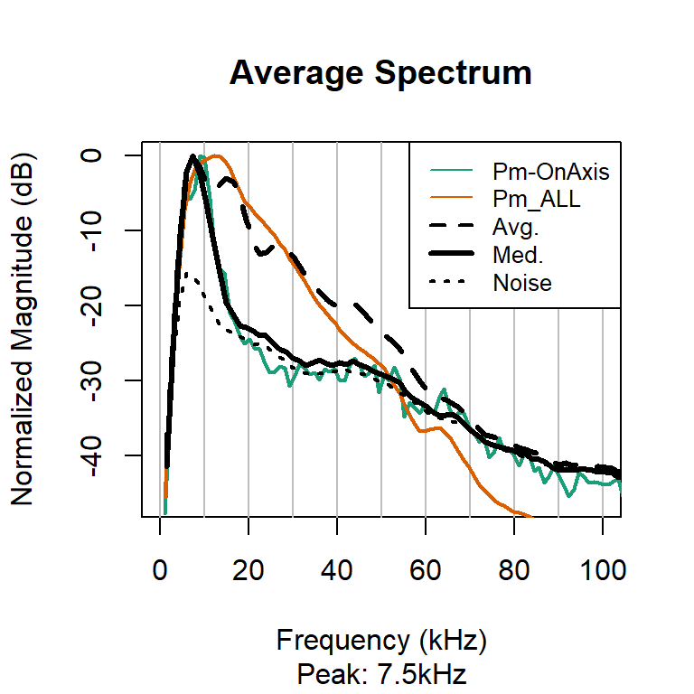

Median statistics for 555 high SNR clicks with SNR >= 15 dB.

| parameter | value |
| --- | --- |
| Median Peak Frequency [kHz] | 6 |
| Median 3dB Center Frequency [kHz] | 6.15 |
| Median 10dB Center Frequency [kHz] | 6.55 |
| Median 3dB Bandwidth [kHz] (lower-upper) | 1.89 (5.19 - 7.02) |
| Median 10dB Bandwidth [kHz] (lower-upper) | 4.7 ( 4 - 9.16) |
| Median duration [μs] (25-75 percentile) | 102 (0 - 285) |

#### Event ID: 6663.241011141801.wav

Time: 2024-10-11 14:18UTC to 2024-10-11 14:24UTC

Event contains 1268 original clicks, **634 valid clicks** after filtering.

##### Click plots and table

SNR histogram includes all filtered clicks. Other plots contain only clicks with SNR >= 15 dB (**n = 508 clicks**) .

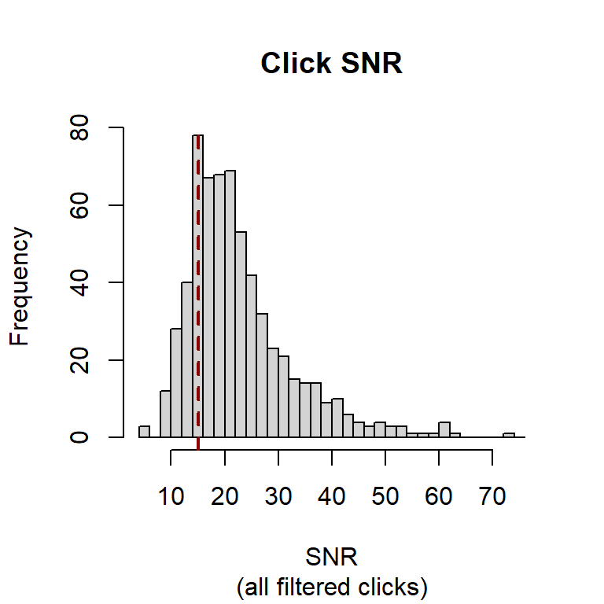

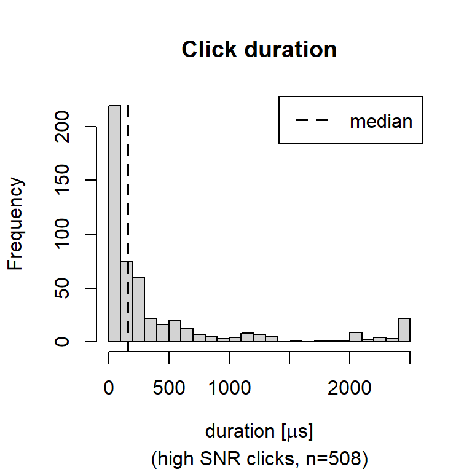

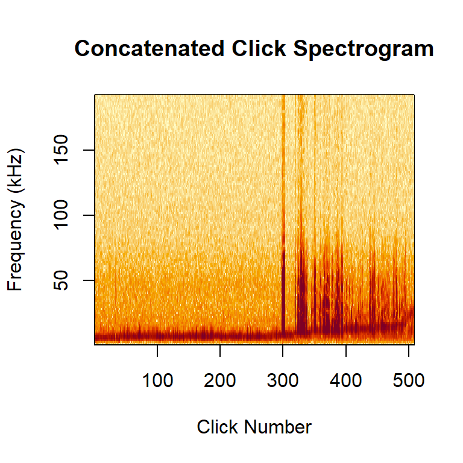

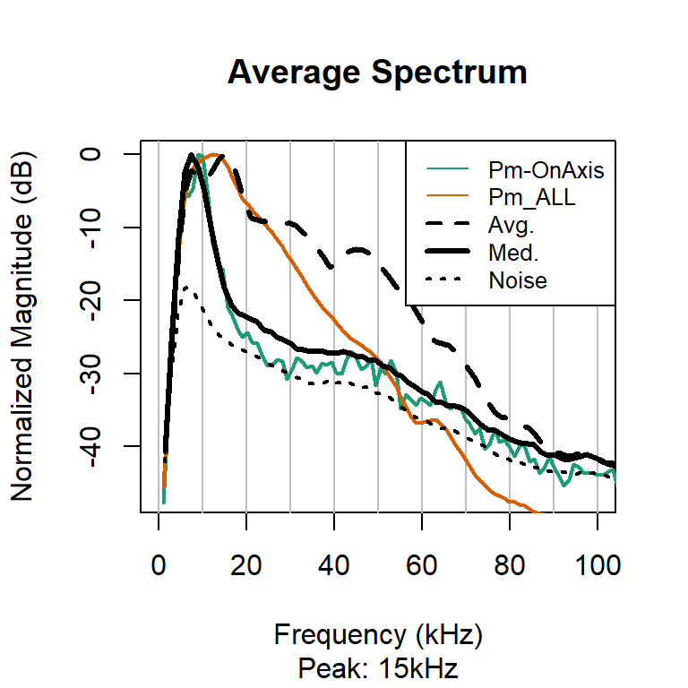

Median statistics for 508 high SNR clicks with SNR >= 15 dB.

| parameter | value |
| --- | --- |
| Median Peak Frequency [kHz] | 6.4 |
| Median 3dB Center Frequency [kHz] | 6.46 |
| Median 10dB Center Frequency [kHz] | 6.56 |
| Median 3dB Bandwidth [kHz] (lower-upper) | 1.89 (5.71 - 7.45) |
| Median 10dB Bandwidth [kHz] (lower-upper) | 4.95 (4.29 - 9.29) |
| Median duration [μs] (25-75 percentile) | 162 (0 - 433) |

#### Event ID: 6663.241011142401.wav

Time: 2024-10-11 14:24UTC to 2024-10-11 14:30UTC

Event contains 974 original clicks, **487 valid clicks** after filtering.

##### Click plots and table

SNR histogram includes all filtered clicks. Other plots contain only clicks with SNR >= 15 dB (**n = 360 clicks**) .

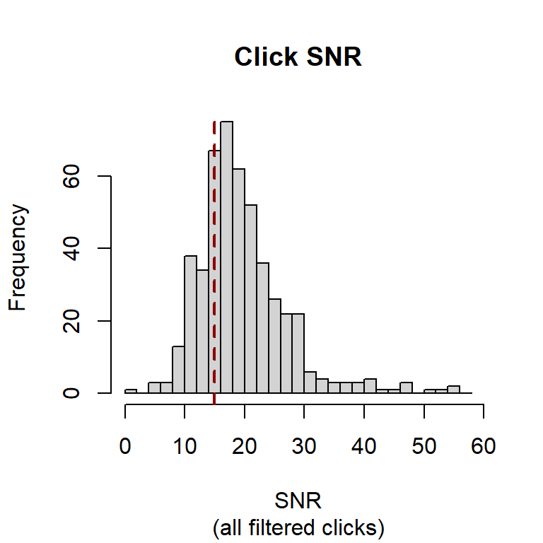

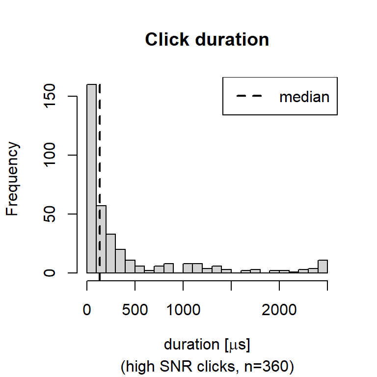

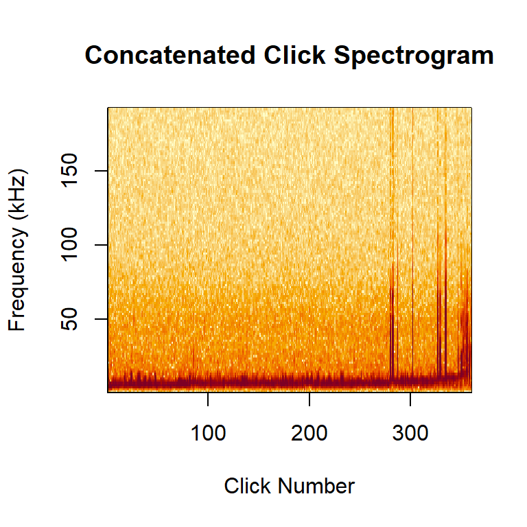

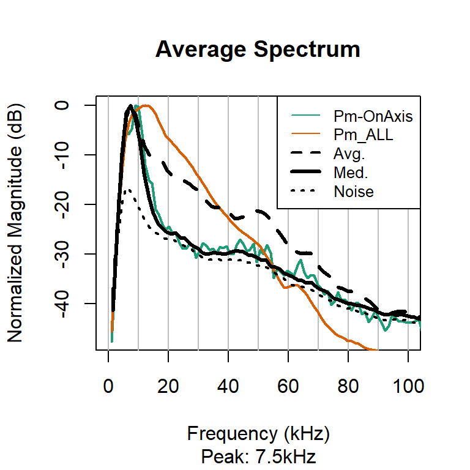

Median statistics for 360 high SNR clicks with SNR >= 15 dB.

| parameter | value |
| --- | --- |
| Median Peak Frequency [kHz] | 6 |
| Median 3dB Center Frequency [kHz] | 5.88 |
| Median 10dB Center Frequency [kHz] | 6.21 |
| Median 3dB Bandwidth [kHz] (lower-upper) | 1.67 (4.85 - 6.76) |
| Median 10dB Bandwidth [kHz] (lower-upper) | 4.5 (3.79 - 8.53) |
| Median duration [μs] (25-75 percentile) | 136 (0 - 400) |

#### Event ID: 6663.241011143001.wav

Time: 2024-10-11 14:30UTC to 2024-10-11 14:36UTC

Event contains 3944 original clicks, **1972 valid clicks** after filtering.

##### Click plots and table

SNR histogram includes all filtered clicks. Other plots contain only clicks with SNR >= 15 dB (**n = 1008 clicks**) .

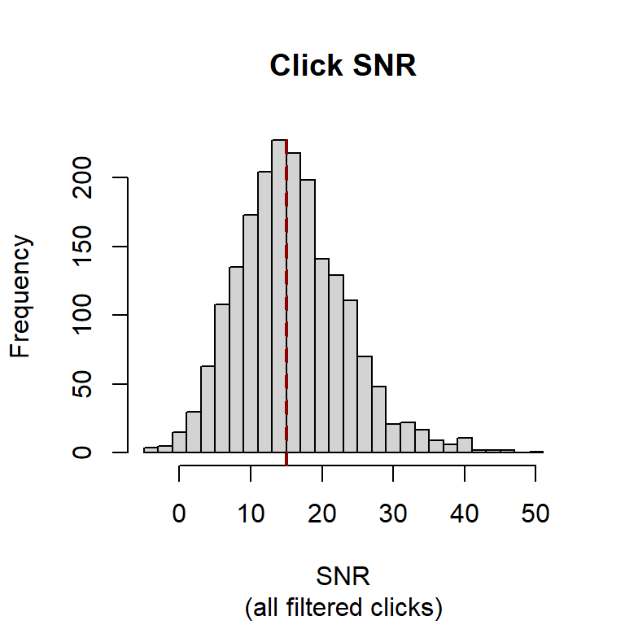

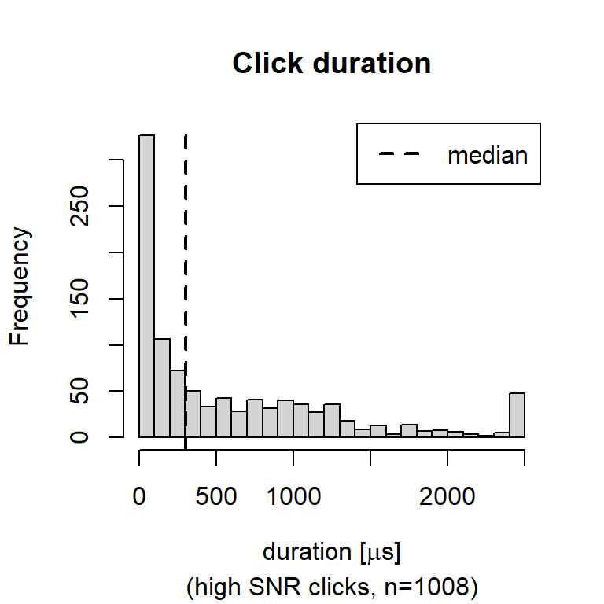

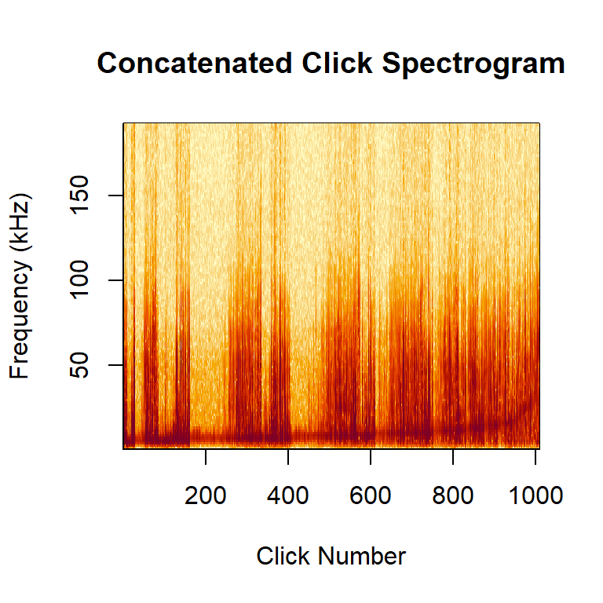

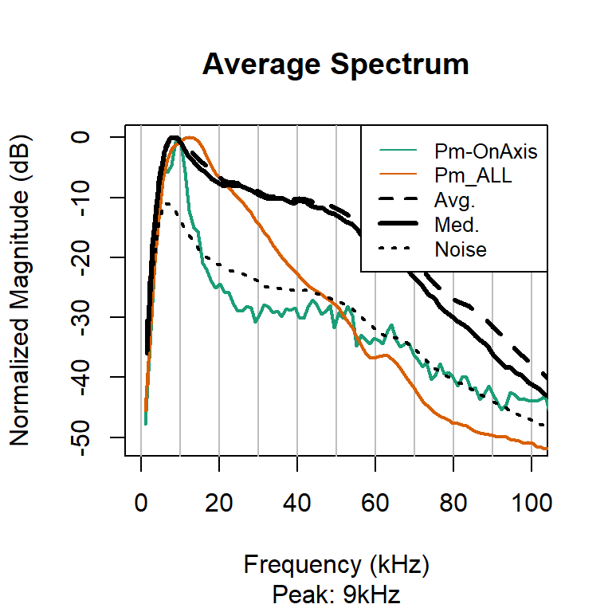

Median statistics for 1008 high SNR clicks with SNR >= 15 dB.

| parameter | value |
| --- | --- |
| Median Peak Frequency [kHz] | 7.2 |
| Median 3dB Center Frequency [kHz] | 6.73 |
| Median 10dB Center Frequency [kHz] | 7.36 |
| Median 3dB Bandwidth [kHz] (lower-upper) | 1.32 (5.93 - 7.53) |
| Median 10dB Bandwidth [kHz] (lower-upper) | 5.17 (4.19 - 10.1) |
| Median duration [μs] (25-75 percentile) | 301 (100 - 1000) |

#### Event ID: 6663.241011143601.wav

Time: 2024-10-11 14:36UTC to 2024-10-11 14:42UTC

Event contains 3310 original clicks, **1655 valid clicks** after filtering.

##### Click plots and table

SNR histogram includes all filtered clicks. Other plots contain only clicks with SNR >= 15 dB (**n = 758 clicks**) .

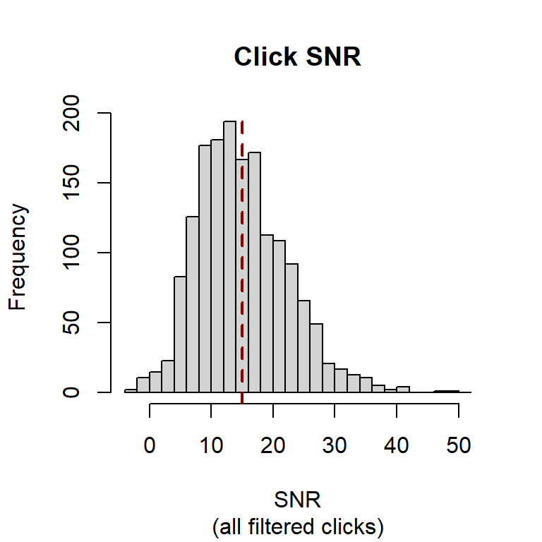

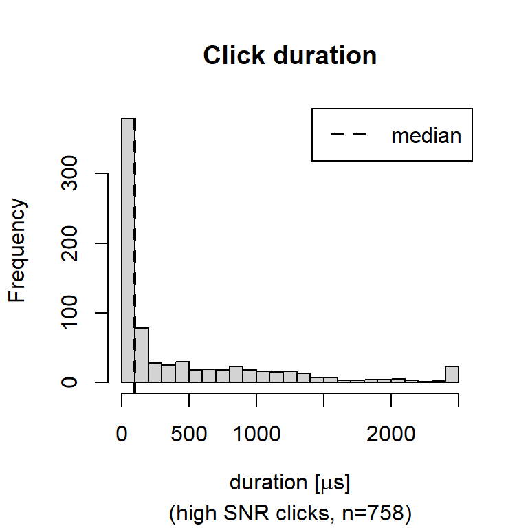

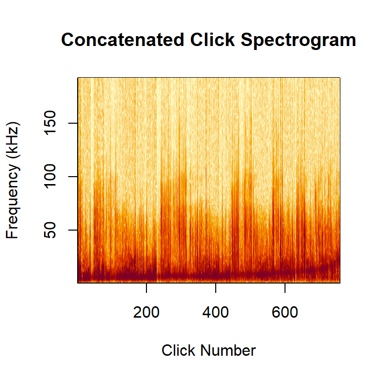

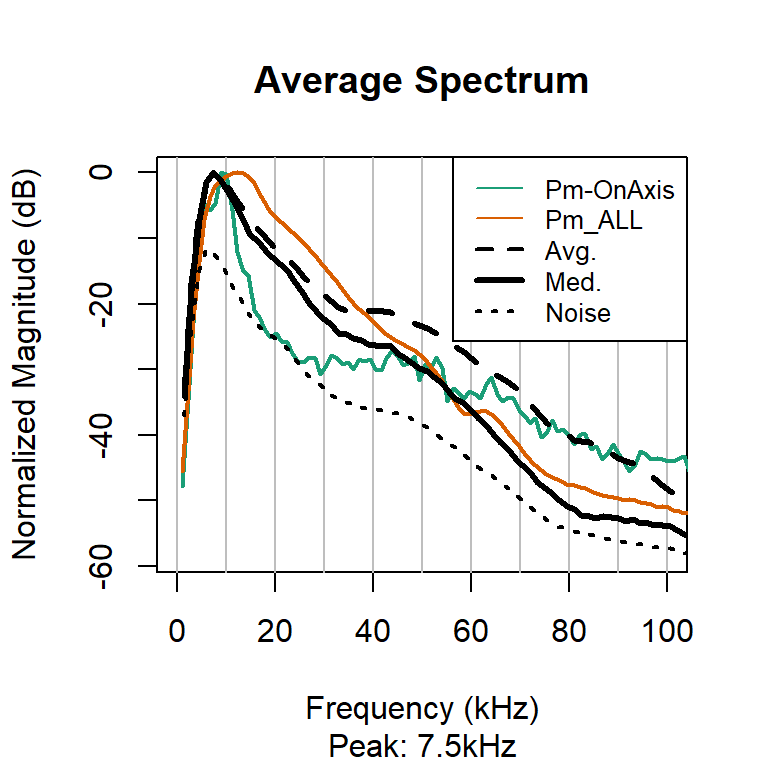

Median statistics for 758 high SNR clicks with SNR >= 15 dB.

| parameter | value |
| --- | --- |
| Median Peak Frequency [kHz] | 6 |
| Median 3dB Center Frequency [kHz] | 5.87 |
| Median 10dB Center Frequency [kHz] | 6.4 |
| Median 3dB Bandwidth [kHz] (lower-upper) | 1.24 (5.13 - 6.66) |
| Median 10dB Bandwidth [kHz] (lower-upper) | 4.95 (3.61 - 9) |
| Median duration [μs] (25-75 percentile) | 100 (10 - 1000) |

### Clean up Event Table

```r
# clean up the event table
evTable <- evTable[evTable$keep == TRUE,]
evTable <- subset(evTable, select = -keep)
# save event table as CSV
write.csv(evTable, file = file.path(params$path_dets,
                                    paste0('eventTable_', params$mission, '_',
                                           params$drift, '_', Sys.Date(),'.csv')))

#dbDisconnect(dbFile)
```

After additional filtering based on median peak frequency, **17 events** events of **1391 original events** remain.